# Part 1: Talk to your slide deck (Multimodal RAG) using foundation models (FMs) hosted on Amazon Bedrock and Amazon SageMaker

*Amit Arora*, *Archana Inapudi*, *Manju Prasad*, *Antara Raisa*

With the advent of generative AI, today’s foundation models (FMs), such as the large language models (LLMs) Claude 2 and Llama 2 can perform a range of (generative) tasks such as question answering, content creation and others on “text” data. Real world data however, exists in multiple modalities such as “text”, “images”, “video” and “audio”. Take a PowerPoint slide deck for example, It could contain information in the form of text, or embedded in graphs, tables and pictures. In this blog, we present a solution that uses Multimodal FMs such as the [Amazon Titan Multimodal Embeddings](https://docs.aws.amazon.com/bedrock/latest/userguide/titan-multiemb-models.html) model and [LLaVA 1.5](https://arxiv.org/pdf/2310.03744.pdf), to perform similar generative tasks on multimodal data.

## Solution overview

The solution presented provides an implementation for answering questions using information contained in the text and visual elements of a slide deck. The design relies on the concept of Retrieval Augmented Generation (RAG). Traditionally, RAG has been associated with textual data that can be processed by LLMs. In this blog, we extend RAG to include images as well. This provides a powerful search capability to extract contextually relevant content from visual elements like tables and graphs along with text.

There are different ways to design a RAG solution that includes images. We have presented one approach here and will follow-up with an alternate approach in the second blog of this three-part blog series.

This solution includes the following components:

- [Amazon Titan Multimodal Embeddings](https://docs.aws.amazon.com/bedrock/latest/userguide/titan-multiemb-models.html) model: this FM is used to generate embeddings for the content in the slide deck used in this blog. As a multimodal model, this Titan model can process text, image or a combination as input and generate embeddings. The Titan Multimodal Embeddings model generates vectors (embeddings) of dimension 1024 and is accessed via the Amazon Bedrock service.
- [Large Language-and-Vision Assistant (LLaVA)](https://llava-vl.github.io/): LLaVA is an open source multimodal model for visual and language understanding and is used to interpret the data in the slides, including visual elements such as graphs and tables. We use the 7-billion parameter version [LLaVA 1.5-7b](https://huggingface.co/liuhaotian/llava-v1.5-7b) in this solution.
- [Amazon SageMaker](https://docs.aws.amazon.com/sagemaker/latest/dg/whatis.html): the LLaVA model to model is deployed on a SageMaker endpoint using SageMaker hosting services and we use the resulting endpoint to run inferences against the LLaVA model. We also use SageMaker Notebooks to orchestrate and demonstrate this solution end-to-end.
- [Amazon OpenSearch Service Serverless](https://docs.aws.amazon.com/opensearch-service/latest/developerguide/serverless-overview.html): OpenSearch Service Serverless is an on-demand serverless configuration for Amazon OpenSearch Service. We use OpenSearch Service Serverless as a vector database for storing embeddings generated by the Titan Multimodal Embeddings model. An index created in the OpenSearch Service Serverless collection serves as the vector store for our RAG solution.
- [Amazon OpenSearch Ingestion](https://docs.aws.amazon.com/opensearch-service/latest/developerguide/ingestion.html) (OSI): OSI is a fully managed, serverless data collector that delivers data to Amazon OpenSearch Service domains and OpenSearch Serverless collections. In this blog, we are using an OSI pipeline to deliver data to the OpenSearch Serverless vector store.

## Solution design

The solution design consists of two parts - Ingestion and User interaction. During ingestion, we process the input slide deck by converting each slide into an image, generate embeddings for these images and then populate the vector data store. These steps are completed prior to the user interaction steps.

In the User interaction phase, a question from the user is converted into embeddings and a similarity search is run on the vector database to find a slide that could potentially contain answers to user question. We then provide this slide (in the form of an image file) to the LLaVA model and the user question as a prompt to generate an answer to the query. All the code for this post is available in the [GitHub](https://github.com/aws-samples/multimodal-rag-on-slide-decks/tree/main/Blog1-TitanEmbeddings-LVM) repo.

### Ingestion steps:

[figure not shown]

Figure 1: Ingestion architecture

1. Slides are converted to image files (one per slide) in the JPG format and passed to the Titan Multimodal Embeddings model to generate embeddings. In our blog, we use this slide deck titled [Train and deploy Stable Diffusion using AWS Trainium & AWS Inferentia](https://d1.awsstatic.com/events/Summits/torsummit2023/CMP301_TrainDeploy_E1_20230607_SPEdited.pdf) from the AWS Summit in Toronto, June 2023 to demonstrate the solution.
   - The sample deck has 31 slides and thus we generate 31 sets of vector embeddings, each with 1024 dimensions. We add additional metadata fields to these generated vector embeddings and create a JSON file. These additional metadata fields can be used to perform rich search queries using OpenSearch’s powerful search capabilities.
2. The generated embeddings are put together in a single JSON file that is uploaded to Amazon S3
3. Via S3 Event Notification, an event is put on the Amazon Simple Queue Service (SQS) queue.
4. This event on the SQS queue acts as a trigger to run the OSI pipeline which in turn ingests the data (JSON file) as documents into the OpenSearch Service Serverless index.
   - Note that the OpenSearch Service Serverless index is configured as the sink for this pipeline and it is created as part of the OpenSearch Service Serverless collection.

### User interaction steps:

[figure not shown]

Figure 2: User interaction architecture

1. A user submits a question related to the slide deck that has been ingested.
2. The user input is converted into embeddings using the Titan Multimodal Embeddings model accessed via Bedrock. An OpenSearch vector search is performed using these embeddings. We perform a K-Nearest Neighbor (`k=1`) search to retrieve the most relevant embedding matching the user query. Setting `k=1` retrieves the most relevant slide to the user question.
3. The metadata of the response from OpenSearch Services Serverless contains a path to the image corresponding to the most relevant slide.
4. A prompt is created by combining the user question and the image path and provided to LLaVA hosted on SageMaker. The LLaVA model is able to understand the user question and answer it by examining the data in the image.
5. Result of this inference is returned to the user.

These steps are discussed in detail in the following sections. See Results section for screenshots and details on the output.

## Prerequisites

To implement the solution provided in this post, you should have an [AWS account](https://signin.aws.amazon.com/signin?redirect_uri=https%3A%2F%2Fportal.aws.amazon.com%2Fbilling%2Fsignup%2Fresume&client_id=signup) and familarity with FMs, Bedrock, SageMaker and OpenSearch Service.

This solution uses the Titan multimodal embeddings model. Ensure that this model is enabled for use in Amazon Bedrock. In AWS Management Console → Amazon Bedrock, select Model access. If Titan Multimodal Embeddings is enabled, the Access status will state “Access granted” as below.

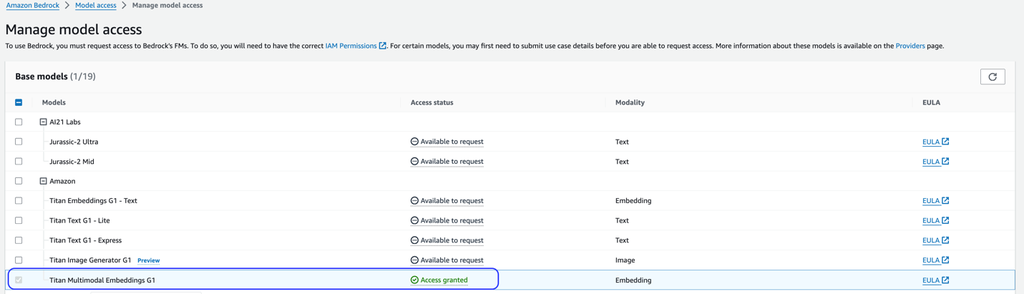

If the model is not available, enable access to the model by clicking on “Manage Model Access”, selecting “Titan Multimodal Embeddings G1” and clicking on Request model access. The model is enabled for use immediately.

[figure not shown]

## Use AWS CloudFormation template to create the solution stack

[output not shown]

After the stack is created successfully, navigate to the stack’s `Outputs` tab on the AWS CloudFormation console and note the values for `MultimodalCollectionEndpoint`, we will use it in the subsequent steps.

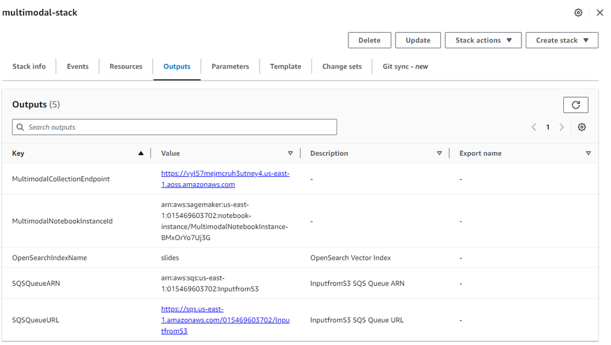

Figure 5: CloudFormation stack outputs

The CloudFormation template creates the following resources:

- `IAM roles`: the following two IAM roles are created. Update these roles to apply least-privilege permissions as discussed in [Security best practices](https://docs.aws.amazon.com/IAM/latest/UserGuide/best-practices.html#grant-least-privilege).
  - `SMExecutionRole` with S3, SageMaker, OpenSearch Service, and Bedrock full access.
  - `OSPipelineExecutionRole` with access to specific SQS and OSI actions.
- `SageMaker Notebook`: all code for this post is run via this notebook.
- `OpenSearch Service Serverless collection`: vector database for storing and retrieving embeddings.
- `OSI Pipeline`: pipeline for ingesting data into OpenSearch Service Serverless.
- `S3 bucket`: all data for this post is stored in this bucket.
- `SQS Queue`: events for triggering the OSI pipeline run are put on this queue.

### OSI pipeline setup

The CloudFormation template sets up the Pipeline configuration required to setup OSI Pipeline with S3-SQS processing as source and OpenSearch Serverless index as sink. Any objects created in the specified S3 bucket and prefix (`multimodal/osi-embeddings-json`) will trigger SQS notifications that will be used by the OSI pipeline to ingest data into OpenSearch Service Serverless.

The CloudFormation template also creates [Network](https://docs.aws.amazon.com/opensearch-service/latest/developerguide/serverless-network.html), [Encryption](https://docs.aws.amazon.com/opensearch-service/latest/developerguide/serverless-encryption.html) and [Data Access](https://docs.aws.amazon.com/opensearch-service/latest/developerguide/serverless-data-access.html) policies required for OpenSearch Serverless Collection. Update these policies to apply least-privilege permissions as discussed in Security best practices.

Note that the CloudFormation template name and OpenSearch Service index name are referenced in the SageMaker notebook `3_rag_inference.ipynb`. If the default names are changed, make sure you update the same in the notebook.

## Testing the solution

Once the prerequisite steps are complete and the CloudFormation stack has been created successfully, we are now ready to run the “talk to your slide deck” implementation:

1. On the SageMaker console, choose **Notebooks** in the navigation pane.
2. Select the `MultimodalNotebookInstance` and choose **Open JupyterLab**.

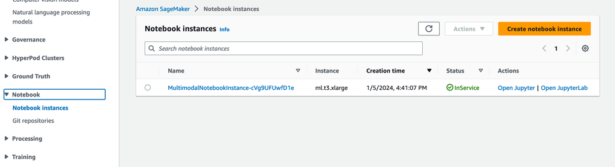

   Figure 6: SageMaker Notebooks

3. In `File Browser`, traverse to the notebooks folder to see notebooks and supporting files. The notebooks are numbered in sequence of execution. Instructions and comments in each notebook describe the actions performed by that notebook. We will run these notebook one by one.
4. Choose `0_deploy_llava.ipynb` to open it in JupyterLab. When the notebook is open, on the Run menu, choose **Run All Cells** to run the code in this notebook. This notebook will deploy the LLaVA-v1.5-7B model to a SageMaker endpoint.
   - In this notebook we download the LLaVA-v1.5-7B model from HuggingFace Hub, replace the `inference.py` script with `llava_inference.py` and create a `model.tar.gz` file for this model.
   - The `model.tar.gz` file is uploaded to S3 and used for deploying the model on SageMaker endpoint. The `llava_inference.py` has additional code to allow reading an image file from S3 and run inference on it.
5. Next Choose `1_data_prep.ipynb` to open it in JupyterLab. When the notebook is open, on the Run menu, choose **Run All Cells** to run the code in this notebook. This notebook will download a publicly available slide deck and convert each slide into the JPG file format and upload these to the S3 bucket for this blog.
6. Next Choose `2_data_ingestion.ipynb` to open it in JupyterLab. When the notebook is open, on the Run menu, choose **Run All Cells** to run the code in this notebook. We do the following in this notebook:
   - Create an index in the OpenSearch Service Serverless collection. This index stores the embeddings data for the slide deck.

   ```python
   session = boto3.Session()
   credentials = session.get_credentials()
   auth = AWSV4SignerAuth(credentials, g.AWS_REGION, g.OS_SERVICE)

   os_client = OpenSearch(
     hosts = [{'host': host, 'port': 443}],
     http_auth = auth,
     use_ssl = True,
     verify_certs = True,
     connection_class = RequestsHttpConnection,
     pool_maxsize = 20
   )

   index_body = """
   {
     "settings": {
         "index.knn": true
     },
     "mappings": {
         "properties": {
             "vector_embedding": {
                 "type": "knn_vector",
                 "dimension": 1024,
                 "method": {
                     "name": "hnsw",
                     "engine": "nmslib",
                     "parameters": {}
                 }
             },
             "image_path": {
                 "type": "text"
             },
             "metadata": {
                 "properties": {
                     "slide_filename": {
                         "type": "text"
                     },
                     "model_id": {
                         "type": "text"
                     },
                     "slide_description": {
                         "type": "text"
                     }
                 }
             }
         }
     }
   }
   """
   index_body = json.loads(index_body)
   try:
     response = os_client.indices.create(index_name, body=index_body)
     logger.info(f"response received for the create index -> {response}")
   except Exception as e:
     logger.error(f"error in creating index={index_name}, exception={e}")
   ```

   - We use Titan Multimodal Embeddings model to convert the JPG images created in the previous notebook into vector embeddings. These embeddings and additional metadata (such as the S3 path of the image file) are stored in a JSON file and uploaded to S3. Note that a single JSON file is created which contains documents for all the slides (images) converted into embeddings. The following code snippet shows how an image (in the form of a Base64 encoded string) is converted into embeddings.

   ```python
   def get_multimodal_embeddings(bedrock: botocore.client, image: str) -> np.ndarray:
       body = json.dumps(dict(inputImage=image))
       try:
           response = bedrock.invoke_model(
               body=body, modelId=g.FMC_MODEL_ID, accept=g.ACCEPT_ENCODING, contentType=g.CONTENT_ENCODING
           )
           response_body = json.loads(response.get("body").read())
           embeddings = np.array([response_body.get("embedding")]).astype(np.float32)
       except Exception as e:
           logger.error(f"exception while image(truncated)={image[:10]}, exception={e}")
           embeddings = None

       return embeddings
   ```

   - This action triggers the OpenSearch Ingestion pipeline ingest process that processes the file and ingests into the OpenSearch Service Serverless Index. Here is a sample of the JSON file created (a vector with 4 dimensions is shown below. Titan Multimodal Embeddings model generates 1024 dimensions).

   ```python
   [
     {
       "image_path": "s3://<your-bucket-name>/path/to/file1.json",
       "metadata": {
         "slide_filename": "mypowerpoint1.pptx",
         "model_id": "amazon.titan-embed-image-v1",
         "slide_description": "This is a test slide deck"
       },
       "vector_embedding": [
         657.6052386529958,
         0.8865137233123771,
         763.870264592026,
         ...
       ]
     }
     ...
   ]
   ```

7. Next Choose `3_rag_inference.ipynb` to open it in JupyterLab. When the notebook is open, on the Run menu, choose **Run All Cells** to run the code in this notebook. This notebook implements the RAG solution: we convert the user question into embeddings, find a similar image (slide) from the vector database and then provide the retrieved image to LLaVA to generate an answer to the user question.
   - We use the following prompt template.

   ```python
   prompt_template: str = """Pretend that you are a helpful assistant that answers questions about content in a slide deck.
     Using only the information in the provided slide image answer the following question.
     If you do not find the answer in the image then say I did not find the answer to this question in the slide deck.

     {question}
   """
   ```

   - The following code snippet provides the RAG workflow.

   ```python
   # create prompt and convert to embeddings
   question: str = "As per the AI/ML flywheel, what do the AWS AI/ML services provide?"
   prompt = prompt_template.format(question=question)
   text_embeddings = get_text_embeddings(bedrock, question)

   # vector db search
   vector_db_response: Dict = find_similar_data(text_embeddings)

   # download image for local notebook display
   s3_img_path = vector_db_response.get('hits', {}).get('hits')[0].get('_source').get('image_path')
   logger.info(f"going to answer the question=\"{question}\" using the image \"{s3_img_path}\"")

   !aws s3 cp {s3_img_path} .
   local_img_path = os.path.basename(s3_img_path)
   display(Image(filename=local_img_path))

   # Ask LLaVA
   data = {
       "image" : s3_img_path,
       "question" : prompt,
       "temperature" : 0.1,
   }
   output = predictor.predict(data)
   logger.info(f"Image={s3_img_path}\nQuestion: {question}\nAnswer: {output}\n\n")
   ```

## Results

Here is a compilation of some user questions and responses generated by our implementation. The Question column captures the user question, and Answer column is the textual response generated by LLaVA. Image is the K-Nearest (`k=1`) slide match returned by the OpenSearch Service Serverless vector search. This slide is interpreted by LLaVA to provide the Answer

Multimodal RAG results

Question

Answer

Image

How does Inf2 compare in performance to comparable EC2 instances? I need numbers.

According to the slide deck, Inf2 instances by AWS Inferentia2 offer up to 4x higher throughput and 10x lower latency compared to comparable EC2 instances.

[figure not shown]

As per the AI/ML flywheel, what do the AWS AI/ML services provide?

The AWS AI/ML services provide better $/perfer capabilities, new capabilities, and investment in innovation.

[figure not shown]

Compared to GPT-2, how many more parameters does GPT-3 have? What is the numerical difference between the parameter size of GPT-2 and GPT-3?

According to the slide, GPT-3 has 175 billion parameters, while GPT-2 has 1.5 billion parameters. The numerical difference between the parameter size of GPT-2 and GPT-3 is 173.5 billion.

[figure not shown]

What are quarks in particle physics?

I did not find the answer to this question in the slide deck.

[figure not shown]

## Tip

Note that you can use OpenSearch Dashboards to interact with the OpenSearch API to run quick tests on your index and ingested data.

[figure not shown]

Figure 7: OpenSearch dashboard GET example

## Cleanup

To avoid incurring future charges, delete the resources. You can do this by deleting the stack from the CloudFormation console.

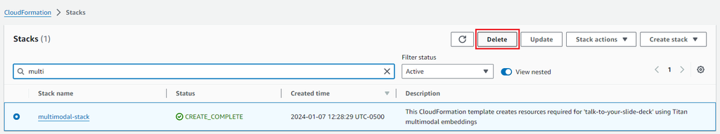

Figure 8: Delete CloudFormation Stack

Additionally, delete the SageMaker Inference Endpoint created for LLaVA inferencing. You can do this by uncommenting the cleanup step in `3_rag_inference.ipynb` and run the cell or by deleting the endpoint from the SageMaker console via SageMaker → Inference → Endpoints and then select and delete the Endpoint.

## Conclusion

Enterprises generate new content all the time and slide decks are a common mechanism used to share and disseminate information internally with the organization and externally with customers or at conferences. Over time, rich information can remain buried and hidden in non-text modalities like graphs and tables in these slide decks. You can use this solution and the power of multimodal FMs such as Titan MultiModal Embeddings mode and LLaVA to discover new information or uncover new perspectives on content in slide decks.

Look out for two additional blogs as part of this series. Blog 2 will cover another approach you could take to “talk to your slide deck”. This approach will generate and store LLaVA inferences and use those stored inferences to respond to user queries. Blog 3 will compare the two approaches.

Portions of this code are released under the Apache 2.0 License as referenced here: https://aws.amazon.com/apache-2-0/

## Author bio

Amit Arora is an AI and ML Specialist Architect at Amazon Web Services, helping enterprise customers use cloud-based machine learning services to rapidly scale their innovations. He is also an adjunct lecturer in the MS data science and analytics program at Georgetown University in Washington D.C.

Manju Prasad is a Senior Solutions Architect within Strategic Accounts at Amazon Web Services. She focuses on providing technical guidance in a variety of domains, including AI/ML to a marquee M&E customer. Prior to joining AWS, she has worked for companies in the Financial Services sector and also a startup.

Archana Inapudi is a Senior Solutions Architect at AWS supporting Strategic Customers. She has over a decade of experience helping customers design and build data analytics, and database solutions. She is passionate about using technology to provide value to customers and achieve business outcomes.

Antara Raisa is an AI and ML Solutions Architect at Amazon Web Services supporting Strategic Customers based out of Dallas, Texas. She also has previous experience working with large enterprise partners at AWS, where she worked as a Partner Success Solutions Architect for digital native customers.